# exploration_template2

### What is the structure of your dataset?

> There were approximately 1,850,000 bike rides in the San Francisco Bay area of California, USA documented

### What is/are the main feature(s) of interest in your dataset?

> Average duration of trips

> Number of daily bike rides

> Gender, and user type

### What features in the dataset do you think will help support your investigation into your feature(s) of interest?

> Trip Duration (seconds), Start Time and Date , End Time and Date, User Type , Member Year of Birth , Member Gender

## Univariate Exploration

> In this section, investigate distributions of individual variables. If you see unusual points or outliers, take a deeper look to clean things up and prepare yourself to look at relationships between variables.

### 1- What is the average duration of trips ?

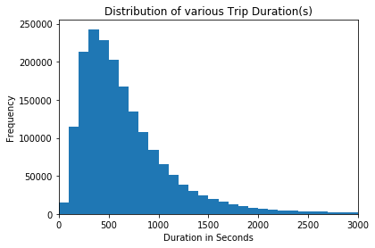

```python
# Here we plot the distribution of trip durations.


binedges = np.arange(0, df_bike_copy['duration_sec'].max() + 100 , 100)
plt.hist(data = df_bike_copy , x = 'duration_sec' , bins = binedges)
plt.xlim(0,3000)
plt.title('Distribution of various Trip Duration(s)')
plt.xlabel('Duration in Seconds')
plt.ylabel('Frequency')
```

> **The distribution of various trip duartion on seconds so will change it to mins to be more understandble**

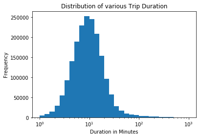

```python
 # Converting the trip durations from seconds to minutes

df_bike_copy['duration_min'] = df_bike_copy['duration_sec'] / 60
df_bike_copy.drop('duration_sec' , axis = 1 , inplace = True)

binedges = 10**np.arange(0 , 3+0.1 , 0.1)
ticks =  [ 0.1 , 0.3 , 1 , 3, 10, 30, 100, 300]
labels = ['{}'.format(v) for v in ticks]
plt.hist(data = df_bike_copy , x = 'duration_min' , bins = binedges);
plt.xticks(ticks,labels);
plt.title('Distribution of various Trip Duration')
plt.xlabel('Duration in Minutes');
plt.ylabel('Frequency')
plt.xscale('log');
```

**As we can see above in the chart the most people taking bikes time (trip) is about 10 mins**

### 2- daily trend of bike rides

```python
def transform_axis_fmt(tick_val, pos):
    if tick_val >= 1000:
        val = int(tick_val/1000)
        return '{:d}K'.format(val)
    elif tick_val >= 1000000:
        val = int(tick_val/1000000)
        return '{:d}M'.format(val)
    else:
        return int(tick_val)
```

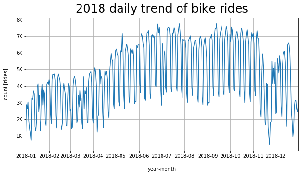

```python
df_clean.groupby('start_time_date').agg('count')['bike_id'].plot(kind = 'line', figsize = [10, 5])
plt.title('2018 daily trend of bike rides', fontsize=24, y=1.015)
plt.xlabel('year-month', labelpad=16)
plt.ylabel('count [rides]', labelpad=16)
ax = plt.gca()
ax.yaxis.set_major_formatter(tick.FuncFormatter(transform_axis_fmt))
plt.grid()
```

**As you can see above , the daily trends of cyclists riding bikes. the number of cyclists above 4k in one month**

### 3-Monthly usage of the bike share system

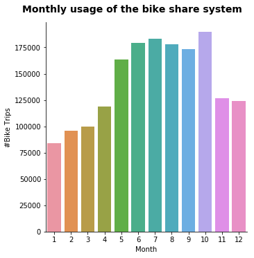

```python
g = sns.catplot(data=df_clean, x='start_time_month', kind='count')
g.set_axis_labels("Month", "#Bike Trips")
g.fig.suptitle('Monthly usage of the bike share system', y=1.03, fontsize=14, fontweight='semibold');
```

**in the summer months and early-mid autumn are the most popular times to use the Ford Go Bike sharing system. October is the most popular month, with July as the second most popular, and June/August coming in closely as the third most popular months to use the bike system**

### 4- weekday usege of the bike sharing system

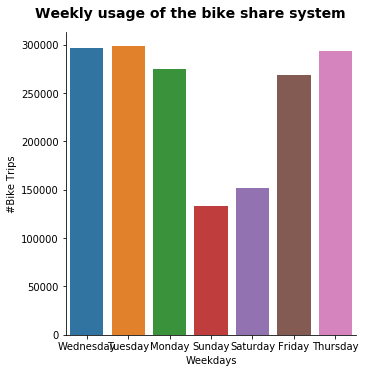

```python
weekday = ['Mon', 'Tue', 'Wed', 'Thu', 'Fri', 'Sat', 'Sun']
g = sns.catplot(data=df_clean, x='start_time_weekday', kind='count')
g.set_axis_labels("Weekdays", "#Bike Trips")
g.fig.suptitle('Weekly usage of the bike share system', y=1.03, fontsize=14, fontweight='semibold');
```

**It looks like the most popular days that cyclists ride their bikes is tuesday and wednesday. The system is most probably used as a daily work/school commute**

### 5- hourly usege of the bike sharing system

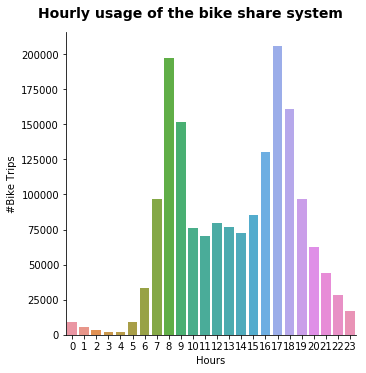

```python
g = sns.catplot(data=df_clean, x='start_time_hour', kind='count')
g.set_axis_labels("Hours", "#Bike Trips")
g.fig.suptitle('Hourly usage of the bike share system', y=1.03, fontsize=14, fontweight='semibold');
```

**The bikes saw the most usage during the morning hours of 8-9am, and in the afternoon hours of 5-6pm, which is a typical workday in the United States. This furthers the suggestion that the bikes are being used primarily for commuters**

### Discuss the distribution(s) of your variable(s) of interest. Were there any unusual points? Did you need to perform any transformations?

> The unusual point is the duration of the bike ride, it gave a hard time to figure out the suration in secondes but it did change ti mins to be more clear.

## Bivariate Exploration

> In this section, investigate relationships between pairs of variables in your data. Make sure the variables that you cover here have been introduced in some fashion in the previous section (univariate exploration).

### In this section I will further explore the dataset by figuring the age group of bike riders and adding the customer type to the analysis.

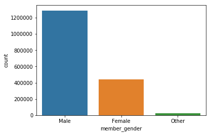

```python
sb.countplot(data = df, x = 'member_gender')
```

**There are significantly more males cyclists than females and other genders**

### 1- Bike rides per member age group

```python
df_clean['member_age_bins'] = df_clean['member_age'].apply(lambda x: '10 - 20' if 10<x<=20
                                                  else '20 - 30' if 20<x<=30
                                                  else '30 - 40' if 30<x<=40
                                                  else '40 - 50' if 40<x<=50
                                                  else '50 - 60' if 50<x<=60
                                                  else x)
```

```python
trip_by_age_df = df_clean.groupby('member_age_bins').agg({'bike_id':'count'})
```

```python
trip_by_age_df['perc'] = (trip_by_age_df['bike_id']/trip_by_age_df['bike_id'].sum())*100
```

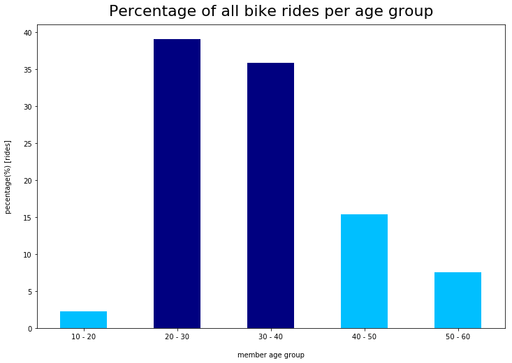

```python
new_color = ['deepskyblue', 'navy', 'navy', 'deepskyblue', 'deepskyblue']
trip_by_age_df['perc'].plot(kind='bar', color=new_color, figsize=(12,8))
plt.title('Percentage of all bike rides per age group', fontsize=22, y=1.015)
plt.xlabel('member age group', labelpad=16)
plt.ylabel('pecentage(%) [rides]', labelpad=16)
plt.xticks(rotation=360)
```

### 2- How does subscribers and customers behave differently?

```python
count_of_rides_per_user_type = df_clean.groupby('user_type').size().reset_index(name='count')
```

```python
# calculating % split for the user type
customer = df_clean.query('user_type == "Customer"')['bike_id'].count()
subscriber = df_clean.query('user_type == "Subscriber"')['bike_id'].count()

customer_proportion = customer / df_clean['bike_id'].count()
subscriber_proportion = subscriber / df_clean['bike_id'].count()
```

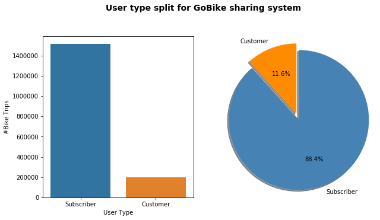

```python
plt.figure(figsize = [10, 5])

# code for the bar chart
plt.subplot(1, 2, 1)

g = sns.countplot(data=df_clean, x="user_type", order=df_clean.user_type.value_counts().index)
g.set_xlabel('User Type')
g.set_ylabel('#Bike Trips')

# code for the pie chart
plt.subplot(1, 2, 2)

labels = ['Customer', 'Subscriber']
sizes = [customer_proportion, subscriber_proportion]
colors = ['darkorange', 'steelblue']
explode = (0, 0.1)

plt.pie(sizes, explode=explode, labels=labels, colors = colors,
        autopct='%1.1f%%', shadow=True, startangle=90)
plt.axis('equal')

plt.suptitle('User type split for GoBike sharing system', y=1.03, fontsize=14, fontweight='semibold');
```

### 3- Average trip duration per user type

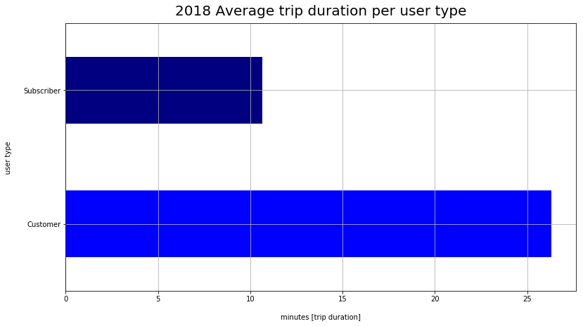

```python
new_color=['blue', 'navy']
ax = df_clean.groupby('user_type')['duration_min'].mean().plot(kind='barh', color=new_color, figsize=(13,7))
ax.set_title('2018 Average trip duration per user type', fontsize=20, y=1.015)
ax.set_ylabel('user type', labelpad=16)
ax.set_xlabel('minutes [trip duration]', labelpad=16)
plt.grid()
```

**As we can deduce from this graph and the one previous, it is understandable that the subscribers has the most frequent rides is because they have shorter trips as opposed to the customerswho has less frequent rides since it takes them longer to ride to their destination**

### 4- Monthly usage of the bike share system

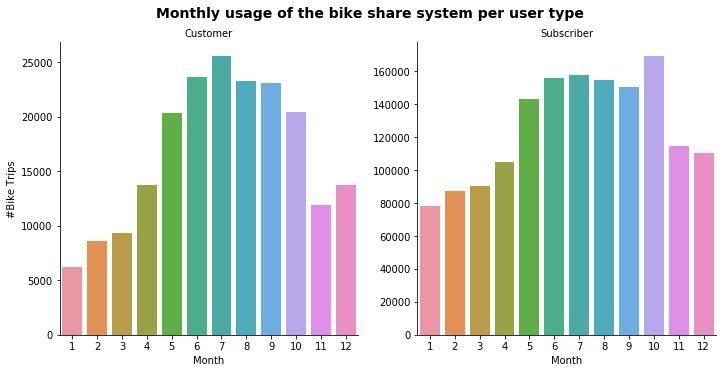

```python
# monthly usege of the bike sharing system per user type
g = sns.catplot(data=df_clean, x='start_time_month', col="user_type", kind='count', sharey = False)

g.set_axis_labels("Month", "#Bike Trips")
g.set_titles("{col_name}")
g.fig.suptitle('Monthly usage of the bike share system per user type', y=1.03, fontsize=14, fontweight='semibold');
```

**Customers: demand is high around summertime, reaching its peak in July. Customers are most probably tourists, or the occasional riders who visit the Bay Area. Subscribers: the highest demand is from May till October, reaching it's peak in October. Subscribers are most likely riders using the bikes for their daily commute**

### 5- weekday usege of the bike sharing system

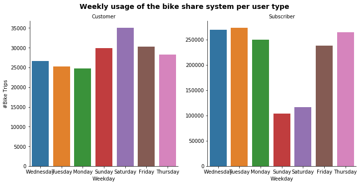

```python
# weekday usege of the bike sharing system per user type

weekday = ['Mon', 'Tue', 'Wed', 'Thu', 'Fri', 'Sat', 'Sun']
g = sns.catplot(data=df_clean, x='start_time_weekday', col="user_type", kind='count' , sharey = False)

g.set_axis_labels("Weekday", "#Bike Trips")
g.set_titles("{col_name}")
g.fig.suptitle('Weekly usage of the bike share system per user type', y=1.03, fontsize=14, fontweight='semibold');
```

**Customers have a relatively low usage of the bike share system with a small increase on the weekends. Subscribers are the opposite**

### 6- hourly usege of the bike sharing system

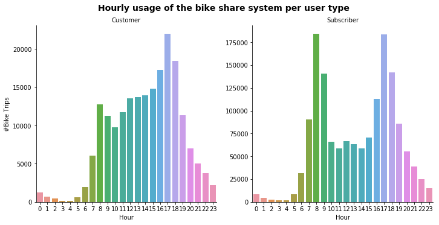

```python
# hourly usege of the bike sharing system per user type

g = sns.catplot(data=df_clean, x='start_time_hour', col="user_type", kind='count', sharey = False)

g.set_axis_labels("Hour", "#Bike Trips")
g.set_titles("{col_name}")
g.fig.suptitle('Hourly usage of the bike share system per user type', y=1.03, fontsize=14, fontweight='semibold');
```

**The bike used from 8-9am and 5-6pm when people get to and gat back from work**

### Talk about some of the relationships you observed in this part of the investigation. How did the feature(s) of interest vary with other features in the dataset?

> Adding the user type to the analysis revealed different behavior usage between customers and subscribers. The data suggests that customers are casual riders such as tourists, or students on a school vacation or holiday

### Did you observe any interesting relationships between the other features (not the main feature(s) of interest)?

> it is understandable that the subscribers has the most frequent rides is because they have shorter trips as opposed to the customerswho has less frequent rides since it takes them longer to ride to their destination

## Multivariate Exploration

> Create plots of three or more variables to investigate your data even further. Make sure that your investigations are justified, and follow from your work in the previous sections.

*Relationships between pairs of variables in the data*

### 1- User trends of bike rides of subscribers vs customers

```python
df_clean.user_type_count_per_year = df_clean.groupby(["start_time_year_month", "user_type"]).size().reset_index()
```

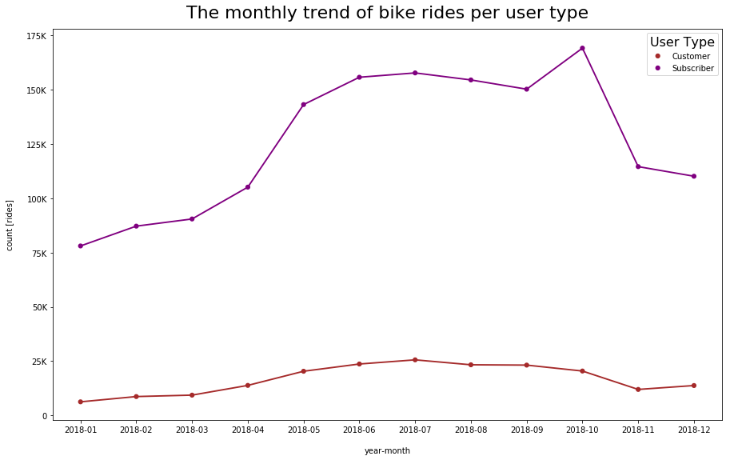

```python
plt.figure(figsize=(15,9))
my_palette = {'Subscriber':'purple', 'Customer':'brown'}
ax = sns.pointplot(x='start_time_year_month', y=0, hue='user_type', palette=my_palette, scale=.7, data=df_clean.user_type_count_per_year )
plt.title('The monthly trend of bike rides per user type', fontsize=22, y=1.015)
plt.xlabel('year-month', labelpad=16)
plt.ylabel('count [rides]', labelpad=16)
leg = ax.legend()
leg.set_title('User Type',prop={'size':16})
ax = plt.gca()
ax.yaxis.set_major_formatter(tick.FuncFormatter(transform_axis_fmt))
```

**Customers' rides seems increasing slightly. There is a decrease on November 2018 for subscribers but it seems like it is related with winter season**

### 2- Average trip distance of subscribers vs customers

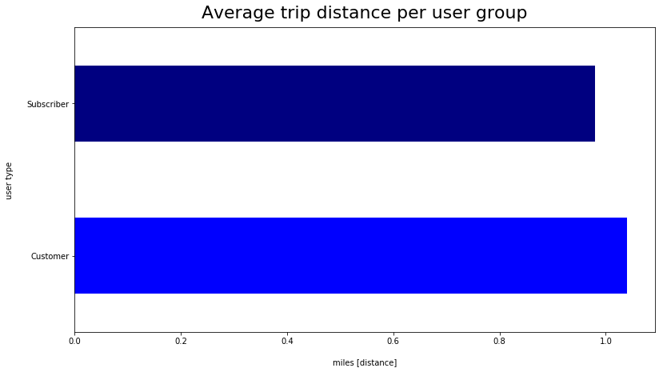

```python
ax = df.groupby('user_type')['distance_miles_estimates'].mean().plot(kind='barh', color=new_color, figsize=(13,7))
ax.set_title('Average trip distance per user group', fontsize=22, y=1.015)
ax.set_ylabel('user type', labelpad=16)
ax.set_xlabel('miles [distance]', labelpad=16)
```

```python
df_clean.customer_age = df_clean[df_clean['user_type']=='Customer'].groupby(['start_time_year_month', 'member_age_bins']).agg({'bike_id':'count'}).reset_index()
```

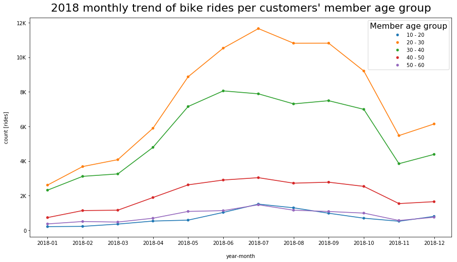

```python
plt.figure(figsize=(15,8))
ax = sb.pointplot(x='start_time_year_month', y='bike_id', hue='member_age_bins',
                  scale=.6, data=df_clean.customer_age)
plt.title("2018 monthly trend of bike rides per customers' member age group", fontsize=22, y=1.015)
plt.xlabel('year-month', labelpad=16)
plt.ylabel('count [rides]', labelpad=16)
leg = ax.legend()
leg.set_title('Member age group',prop={'size':16})
ax = plt.gca()
ax.yaxis.set_major_formatter(tick.FuncFormatter(transform_axis_fmt))
```

### Were there any interesting or surprising interactions between features?

> It 's interesting because in my data I did an anlaysis between subscribers and customer and I did figured there is different data between each other. It depends on other things like weather and timining.

> At the end of your report, make sure that you export the notebook as an html file from the `File > Download as... > HTML` menu. Make sure you keep track of where the exported file goes, so you can put it in the same folder as this notebook for project submission. Also, make sure you remove all of the quote-formatted guide notes like this one before you finish your report!